# Final Lecture – UML Design: A Comprehensive Summary

Traian Florin Șerbănuță

2025

### Goal

Consolidate UML knowledge, reflect on modeling choices, and connect diagrams, design patterns, and evaluation techniques.

### Agenda

1. Why UML still matters
2. UML diagram landscape (overview)
3. Behavioral modeling recap
4. Structural modeling recap
5. Design patterns & architecture recap
6. Model evaluation & quality
7. Reflection & discussion exercises

# Foundations & Behavioral View

# Why UML?

- Common visual language for software design
- Supports **analysis → design → implementation → testing**
- Bridges communication gaps between stakeholders
- Enables reasoning before code exists

> UML is not about drawing diagrams — it is about *thinking structurally and behaviorally*.

# UML Diagram Landscape

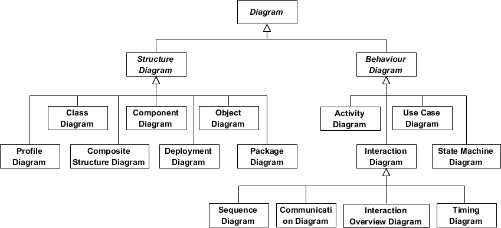

# Behavioral Modeling – What We Learned

### Use Case Diagrams

- Capture system *goals*, not implementation
- Define system boundary and actors

### Sequence & Communication Diagrams

- Describe object interactions over time
- Message consistency with class operations

### State Diagrams

- Model lifecycle and event-driven behavior
- Excellent for controllers, protocols, devices

### Activity Diagrams

- Model workflows and business logic
- Emphasize concurrency and control flow

# Interactive Discussion

### Prompt

- Which behavioral diagram did you find *most useful*?
- Which one felt *least intuitive*?
- Where did diagrams help clarify misunderstandings?

Students discuss in small groups → short plenary feedback.

# Structure, Design & Evaluation

# Structural Modeling – What We Learned

### Class & Object Diagrams

- Static structure vs runtime snapshots
- Responsibility-driven design

### Package Diagrams

- Manage complexity
- Support layering and modularization

### Component & Deployment Diagrams

- Architectural view
- Mapping software to hardware

### Composite Structure Diagrams

- Internal structure of complex classifiers

# UML Meta-Model & Profiles

- UML defined using MOF (M3 → M2 → M1 → M0)
- Profiles customize UML for domains
- Stereotypes, tagged values, constraints

> Profiles adapt UML *without changing the language itself*.

# Design Patterns Recap

### Categories

- **Creational**: Builder, Singleton, Factory Method
- **Structural**: Bridge, Adapter, Decorator, Proxy, Composite
- **Behavioral**: Iterator, Observer, State, Visitor, Mediator

### Key Lesson

- Patterns encode *proven design decisions*
- UML helps document and communicate patterns

# Evaluating & Testing UML Models

### Evaluation Dimensions

- Syntactic
- Semantic
- Pragmatic
- Organizational
- Technical

### Techniques

- Reviews & checklists
- Cross-diagram consistency
- OCL constraints
- Simulation & model-based testing

# Interactive Exercise (Group Task)

### Choose one of the following

1. A UML diagram type you used in a project
2. A design pattern from the course
3. A modeling mistake you now recognize

### Discuss

- What problem does it solve well?
- When would it *not* be appropriate?
- How would you explain it to a junior engineer?

Each group shares **one insight**.

# Final Reflection

- UML is a *toolbox*, not a checklist
- Choose diagrams intentionally
- Prefer clarity over completeness
- Models should evolve with understanding

> Good models ask good questions — not just provide answers.

# Closing & Course Takeaways

- You can now **read, critique, and design** UML models
- You understand how diagrams relate and complement each other
- You can evaluate model quality and apply patterns consciously

**Thank you for the engagement throughout the course!**